# Statistical and Machine Learning

Lab7: Ensemble Learning - Bagging and Boosting

Tsai, Dai-Rong

## Dataset

> *Sonar, Mines vs. Rocks*

The task is to discriminate between sonar signals bounced off a metal cylinder and those bounced off a roughly cylindrical rock.

```r
# Set random seed
set.seed(123)

# Packages
library(randomForest) # for randomForest
library(adabag) # for boosting
library(rpart.plot) # for rpart.plot
library(caTools) # for LogitBoost

# Data
data(Sonar, package = "mlbench")
```

- Response
  - `Class`: `"R"` if the object is a rock and `"M"` if it is a mine (metal cylinder).
- Predictors
  - `V1` to `V60`: the energy within a particular frequency band, integrated over a certain period of time.
- Preview
- Data Structure

```r
dim(Sonar)
```

```
[1] 208  61
```

```r
head(Sonar)[c(1:5)]
head(Sonar)[c(56:61)]
```

```
      V1     V2     V3     V4     V5
1 0.0200 0.0371 0.0428 0.0207 0.0954
2 0.0453 0.0523 0.0843 0.0689 0.1183
3 0.0262 0.0582 0.1099 0.1083 0.0974
4 0.0100 0.0171 0.0623 0.0205 0.0205
5 0.0762 0.0666 0.0481 0.0394 0.0590
6 0.0286 0.0453 0.0277 0.0174 0.0384
```

```
     V56    V57    V58    V59    V60 Class
1 0.0167 0.0180 0.0084 0.0090 0.0032     R
2 0.0191 0.0140 0.0049 0.0052 0.0044     R
3 0.0244 0.0316 0.0164 0.0095 0.0078     R
4 0.0073 0.0050 0.0044 0.0040 0.0117     R
5 0.0015 0.0072 0.0048 0.0107 0.0094     R
6 0.0089 0.0057 0.0027 0.0051 0.0062     R
```

```r
table(Sonar$Class)
```

```
  M   R
111  97
```

```r
str(Sonar)
```

```
'data.frame':   208 obs. of  61 variables:
 $ V1   : num  0.02 0.0453 0.0262 0.01 0.0762 0.0286 0.0317 0.0519 0.0223 0.0164 ...
 $ V2   : num  0.0371 0.0523 0.0582 0.0171 0.0666 0.0453 0.0956 0.0548 0.0375 0.0173 ...
 $ V3   : num  0.0428 0.0843 0.1099 0.0623 0.0481 ...
 $ V4   : num  0.0207 0.0689 0.1083 0.0205 0.0394 ...
 $ V5   : num  0.0954 0.1183 0.0974 0.0205 0.059 ...
 $ V6   : num  0.0986 0.2583 0.228 0.0368 0.0649 ...
 $ V7   : num  0.154 0.216 0.243 0.11 0.121 ...
 $ V8   : num  0.16 0.348 0.377 0.128 0.247 ...
 $ V9   : num  0.3109 0.3337 0.5598 0.0598 0.3564 ...
 $ V10  : num  0.211 0.287 0.619 0.126 0.446 ...
 $ V11  : num  0.1609 0.4918 0.6333 0.0881 0.4152 ...
 $ V12  : num  0.158 0.655 0.706 0.199 0.395 ...
 $ V13  : num  0.2238 0.6919 0.5544 0.0184 0.4256 ...
 $ V14  : num  0.0645 0.7797 0.532 0.2261 0.4135 ...
```

[output cut: 47 more lines]

## Create Training/Testing Partitions

- Split data into 70% training set and 30% test set

```r
nr <- nrow(Sonar)
train.id <- sample(nr, nr * 0.7)

training <- Sonar[train.id, ]
testing <- Sonar[-train.id, ]
```

- Check dimension

```r
dim(training)
```

```
[1] 145  61
```

```r
dim(testing)
```

```
[1] 63 61
```

# Bagging: Bootstrap Aggregating

## Bagging for CART

Bagging for CART is simply a special case of a random forest with $m = p$.

```r
bag.tree <- randomForest(Class ~ ., data = training,
                         mtry = ncol(training)-1,
                         importance = TRUE)
bag.tree
```

```
Call:
 randomForest(formula = Class ~ ., data = training, mtry = ncol(training) -      1, importance = TRUE)
               Type of random forest: classification
                     Number of trees: 500
No. of variables tried at each split: 60

        OOB estimate of  error rate: 18.62%
Confusion matrix:
   M  R class.error
M 64 11     0.14667
R 16 54     0.22857
```

The argument `mtry = ncol(training)-1` indicates that all 60 predictors should be considered for each split of the tree.

**Arguments**

- `ntree`: (default: 500) Number of trees to grow.
- `mtry`: Number of variables randomly sampled as candidates at each split. The default values are different for classification ($\sqrt{p}$ where $p$ is number of predictors) and regression ($\frac{p}{3}$).
- `nodesize`: Minimum size of terminal nodes. The default value is `1` for classification and `5` for regression.
- `importance`: Whether importance of predictors is assessed.

## Random Forest

```r
rf <- randomForest(Class ~ ., data = training,
                   mtry = floor(sqrt(ncol(training)-1)), # default for classification
                   importance = TRUE)
rf
```

```
Call:
 randomForest(formula = Class ~ ., data = training, mtry = floor(sqrt(ncol(training) -      1)), importance = TRUE)
               Type of random forest: classification
                     Number of trees: 500
No. of variables tried at each split: 7

        OOB estimate of  error rate: 17.24%
Confusion matrix:
   M  R class.error
M 64 11     0.14667
R 14 56     0.20000
```

[figure not shown]

```r
plot(rf, lty = 1, main = "OOB Error for Bagging")
legend("topright", colnames(rf$err.rate), col = 1:3, lty = 1)
```

### Tune `randomForest` for the optimal `mtry` parameter

**Arguments**

- `mtryStart`: starting value of `mtry`; default is the same as in `randomForest()`.
- `ntreeTry`: number of trees used at the tuning step.
- `stepFactor`: at each iteration, `mtry` is inflated (or deflated) by this value.
- `improve`: the (relative) improvement in OOB error must be by this much for the search to continue.

```
mtry = 7  OOB error = 16.55%
Searching left ...
mtry = 5    OOB error = 13.79%
0.16667 0.01
mtry = 4    OOB error = 14.48%
-0.05 0.01
Searching right ...
mtry = 10   OOB error = 19.31%
-0.4 0.01
```

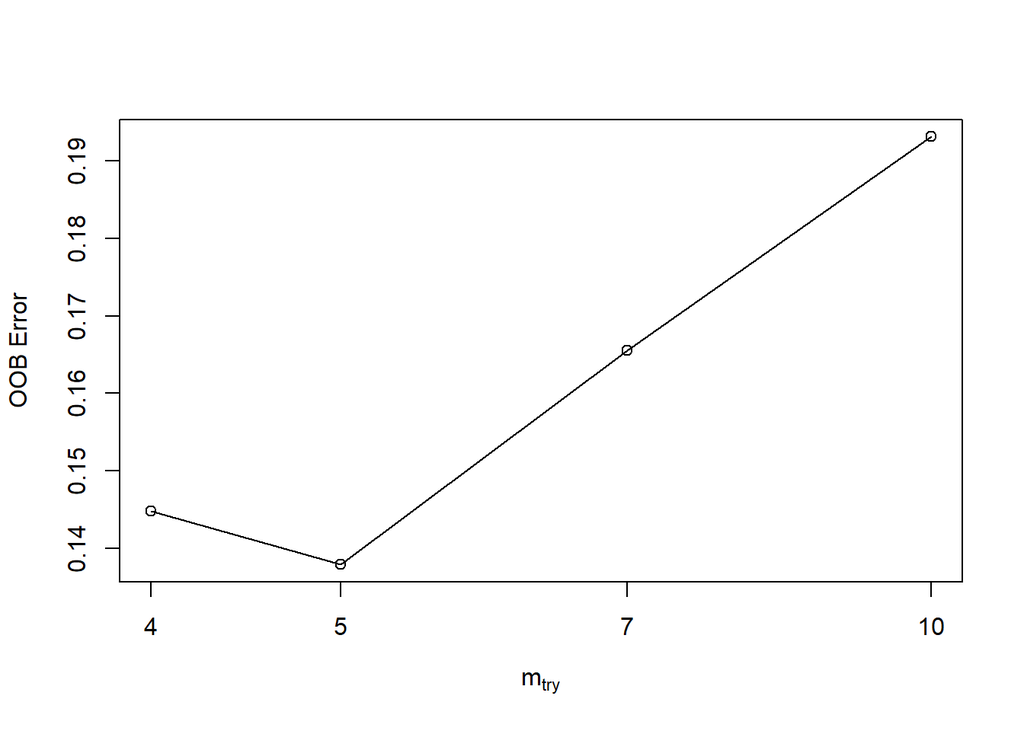

```r
mtry.tuned <- tuneRF(x = training[, -61], y = training[, 61],
                     ntreeTry = 200, stepFactor = 1.5, improve = 0.01)
```

```r
mtry.tuned
```

```
       mtry OOBError
4.OOB     4  0.14483
5.OOB     5  0.13793
7.OOB     7  0.16552
10.OOB   10  0.19310
```

```r
rf.tuned <- randomForest(Class ~ ., data = training,
                         mtry = mtry.tuned[which.min(mtry.tuned[, 2]), 1],
                         importance = TRUE)
```

### Variable Importance

**Definitions**

- **Mean decrease in accuracy**<sup>1</sup> (`type = 1`)

  The prediction error (error rate for classification, MSE for regression) on the OOB samples is recorded for each tree. Then the same is done after *permuting each predictor variable*. The difference between the two are then averaged over all trees, and normalized by the standard deviation of the differences.
- **Mean decrease in node impurity** (`type = 2`)

  Add up the total amount that the node impurity (Gini index for classification, RSS for regression) is decreased due to splits over a given predictor, averaged over all trees.

```r
importance(rf.tuned, type = 1)
```

```
    MeanDecreaseAccuracy
V1               4.67849
V2               0.47360
V3               1.84857
V4               3.46161
V5               2.16967
V6               1.71116
V7              -1.01116
V8               0.15539
V9               5.90475
V10              8.18567
 [ reached getOption("max.print") -- omitted 50 rows ]
```

```r
importance(rf.tuned, type = 2)
```

```
    MeanDecreaseGini
V1           1.11360
V2           0.69402
V3           0.86792
V4           1.52303
V5           1.07480
V6           0.64202
V7           0.48469
V8           0.51134
V9           1.97858
V10          2.81816
 [ reached getOption("max.print") -- omitted 50 rows ]
```

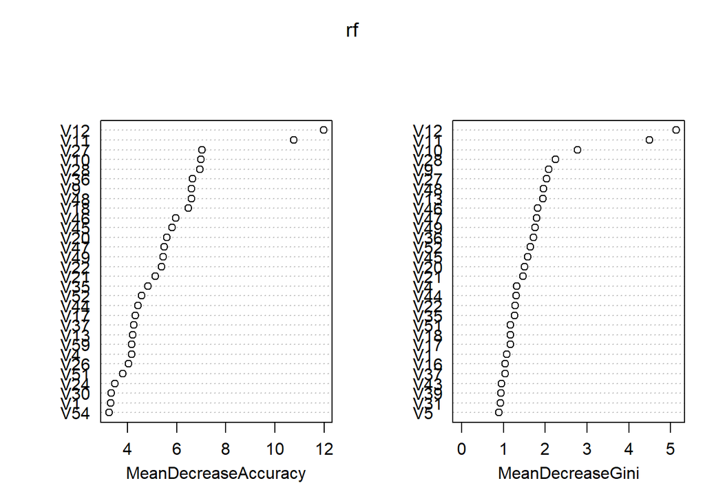

```r
varImpPlot(rf)
```

[^1]: Christoph Molnar. [**Permutation Feature Importance**](https://christophm.github.io/interpretable-ml-book/feature-importance.html#feature-importance). *Interpretable Machine Learning*.

### Comparison bwtween Bagging and Random Forest

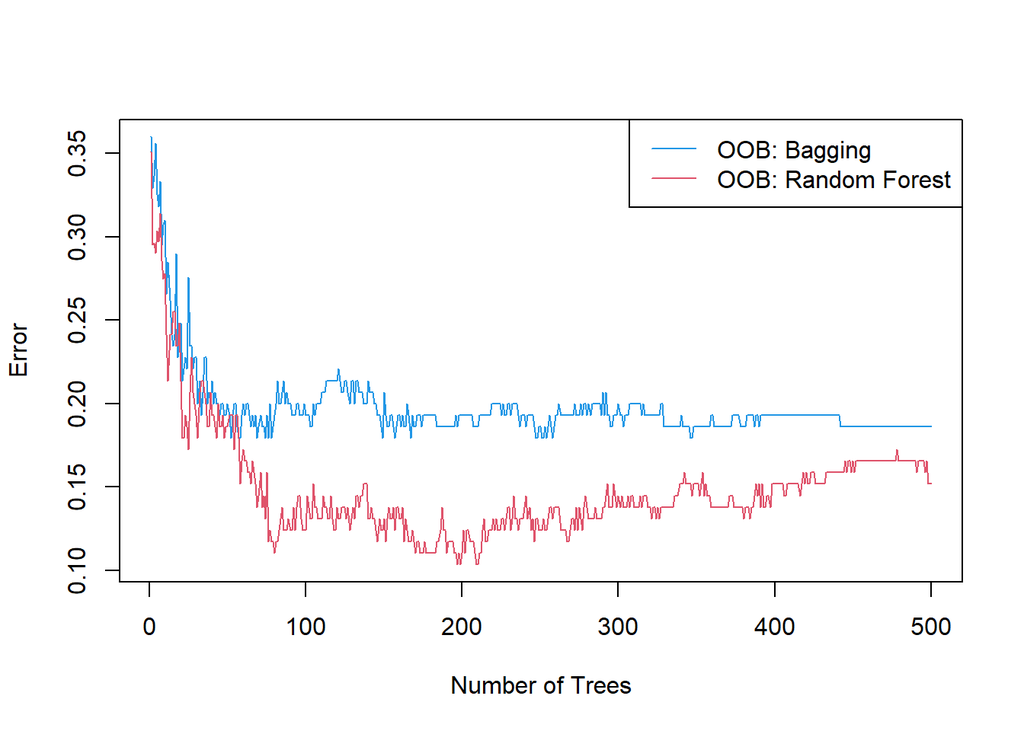

```r
oob.err <- cbind(bag = bag.tree$err.rate[, "OOB"], rf = rf.tuned$err.rate[, "OOB"])
matplot(1:bag.tree$ntree, oob.err,
        type = 'l', col = c(4, 2), lty = 1, xlab = "Number of Trees", ylab = "Error")
legend("topright", c("OOB: Bagging", "OOB: Random Forest"), col = c(4, 2), lty = 1)
```

# Boosting

## AdaBoost: Adaptive Boosting

```r
adabst <- boosting(Class ~ ., data = training, mfinal = 500,
                   control = rpart.control(maxdepth = 3))
```

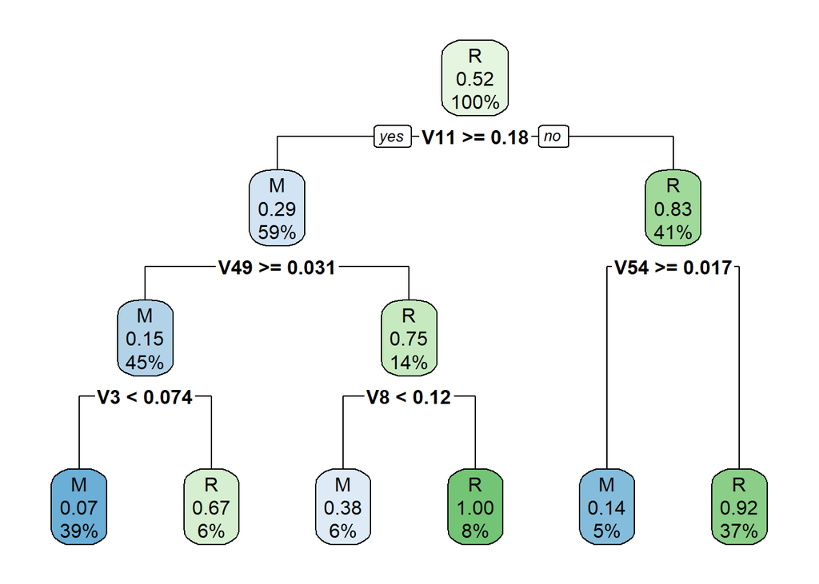

Tree 1

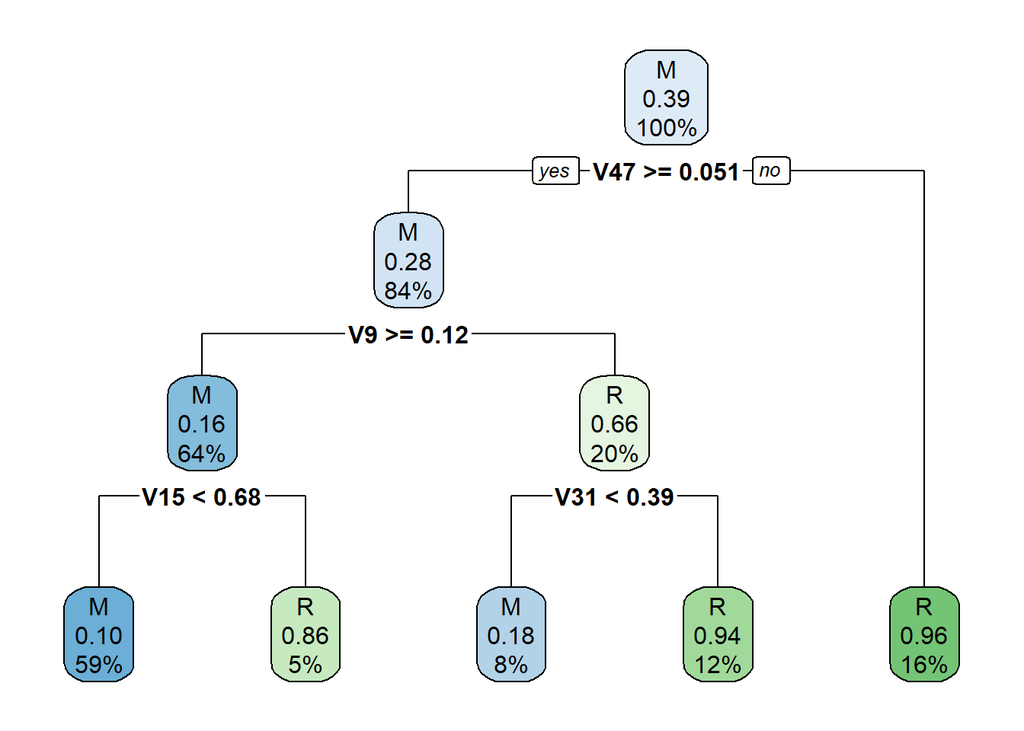

Tree 2

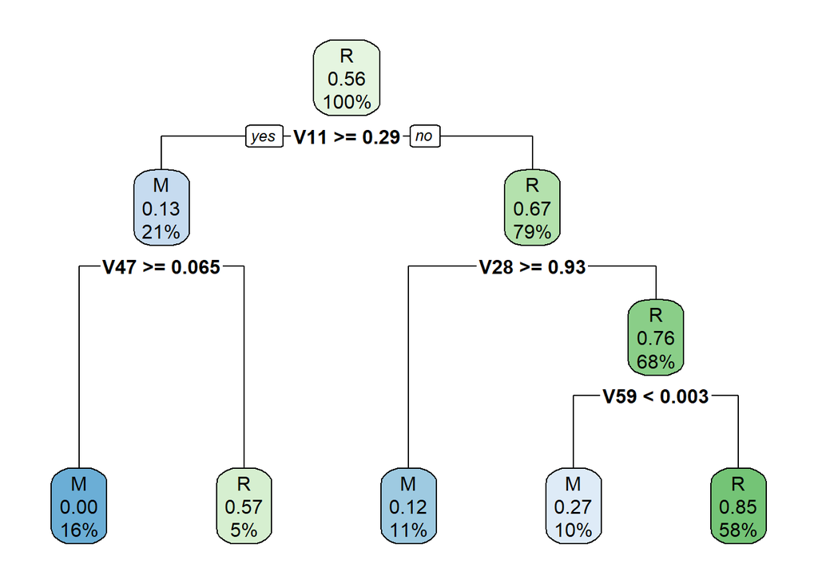

Tree 500

```r
rpart.plot(adabst$trees[[1]], roundint = FALSE)
rpart.plot(adabst$trees[[2]], roundint = FALSE)
rpart.plot(adabst$trees[[500]], roundint = FALSE)
```

```r
adabst$weights
```

```
  [1] 0.71498 0.65161 0.62054 0.85824 0.74224 0.57313 0.77478 0.65023 0.43295 0.58170 0.75750
 [12] 0.50777 0.60344 0.74467 0.53264 0.73768 0.89145 0.62453 0.71709 0.41609 0.58745 0.81290
 [23] 0.72682 0.66464 0.61201 0.49131 0.87371 0.63093 0.57654 0.56973 0.61440 0.81763 0.68532
 [34] 0.65630 0.69274 0.82753 0.63081 0.60243 0.58930 0.78998 0.82028 0.57802 0.63757 0.90656
 [45] 0.56327 0.67314 0.72367 0.63465 0.76832 0.51324 0.59855 0.82898 0.80429 0.66021 0.80936
 [56] 0.64225 0.42011 0.48955 0.71835 0.69398 0.46438 0.69322 0.65157 0.53291 0.94003 0.64208
 [67] 0.55409 0.69399 0.68418 0.58002 0.41933 0.51084 0.77857 0.64927 0.59660 0.57998 0.65635
 [78] 0.66201 0.49327 0.75239 0.59229 0.61135 0.72330 0.53381 0.57918 0.76733 0.64537 0.75715
 [89] 0.62843 0.77519 0.76389 0.82021 0.53233 0.78548 0.63956 0.75681 0.81294 0.73684 0.80244
[100] 0.73449
 [ reached getOption("max.print") -- omitted 400 entries ]
```

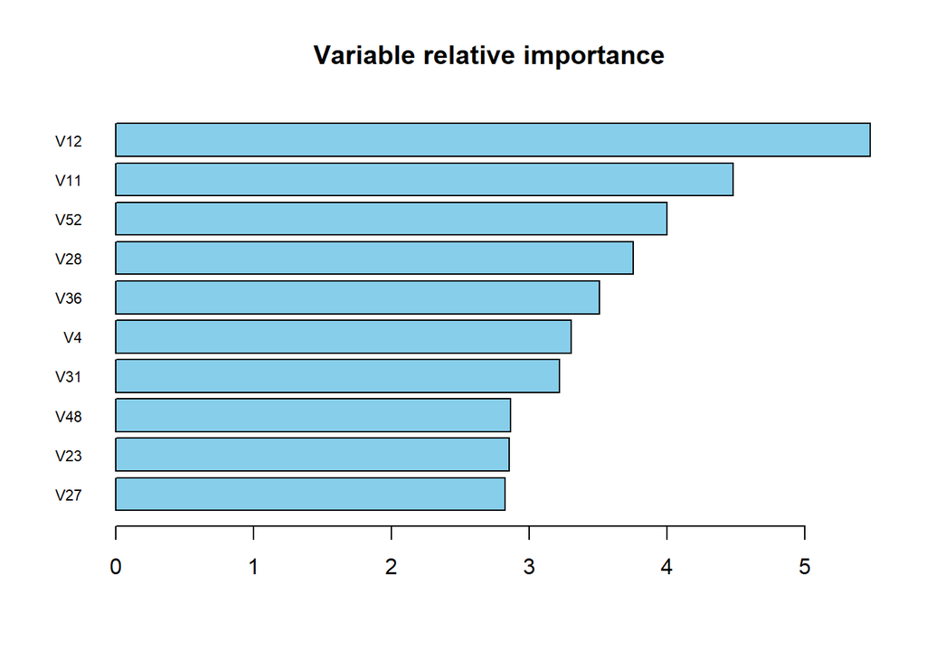

```r
# importanceplot(adabst, horiz = TRUE, cex.names = 0.7)
vimp10 <- sort(adabst$importance, decreasing = TRUE)[1:10]
barplot(rev(vimp10), horiz = TRUE, las = 1,
        cex.names = 0.7, col = "skyblue",
        main = "Variable relative importance")
```

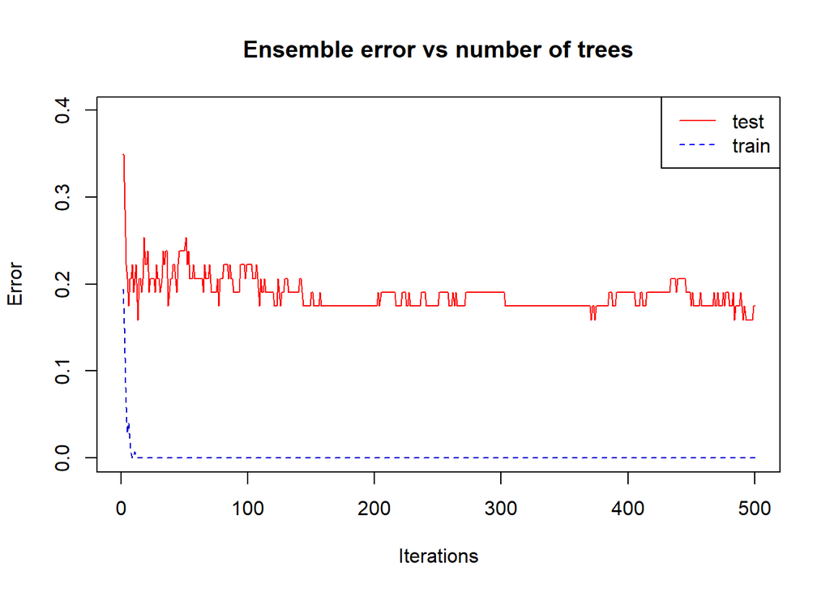

```r
evol.train <- errorevol(adabst, newdata = training)
evol.test <- errorevol(adabst, newdata = testing)
plot.errorevol(evol.test, evol.train)
```

## LogitBoost

```r
logitbst <- LogitBoost(xlearn = training[, -61],
                       ylearn = training[, 61],
                       nIter = 501)
```

**Note**

`Logitboost` algorithm relies on a voting scheme to make classifications. Many (`nIter` of them) weak classifiers are applied to each sample and their findings are used as votes to make the final classification. It’s common for two cases have a tie (the same number of votes), especially if `nIter` is even. In that case `predict()` returns `NA`, instead of a label.

## Gradient Boosting

[figure not shown]

## Prediction

```r
pred.bag.tree <- predict(bag.tree, testing)
pred.rf.tuned <- predict(rf.tuned, testing)
pred.adabst <- predict(adabst, testing)$class
pred.logitbst <- predict(logitbst, testing)

acc <- sapply(mget(ls(pattern = "^pred")), \(x) mean(x == testing$Class))
```

```r
sort(acc)
```

```
bag.tree logitbst rf.tuned   adabst
 0.68254  0.79365  0.79365  0.82540
```

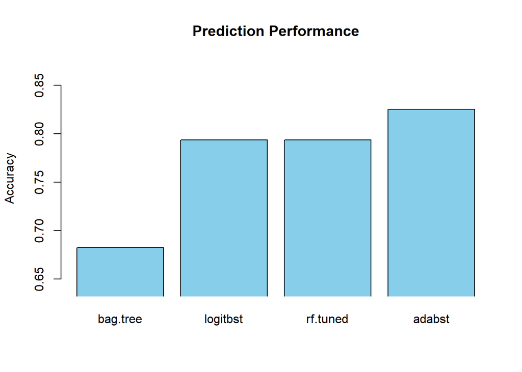